# Bio334 Exercise 5 (Robinson): Single-cell RNA-seq session

Almut Lütge, Helena L Crowell, Anthony Sonrel, Mark Robinson

Compiled: June 02, 2022

# Background

During the last years, single cell RNAseq became a popular method in the field of genomics. Different technologies and protocols were developed and optimized in parallel. Some of them were generated to perform a specific subtask (e.g. single nucleus sequencing), while most of them differ in the number of cells that could be processed and sequencing depth (the amount of the cell’s total RNA that is sequenced) that can be achieved. Well known technologies are:

- [10X Chromium](https://www.10xgenomics.com/products/single-cell-gene-expression/), which enables sequencing of tens of thousands of cells at relatively low cost, but to a comparably shallow depth.
- Dropseq, a non-commercial protocol with lower throughput than 10X chromium.
- [CELseq](https://emea.illumina.com/science/sequencing-method-explorer/kits-and-arrays/cel-seq.html), which also has a lower throughput, but highest sequencing depth.

# Dataset

## Getting started

Start by loading the `CellBench` package and the dataset. The data are stored in a list with one `SingleCellExperiment` object for each technology (see below). Make yourself familiar with the objects:

- How many *cells* do we have for each technology?
- How many *genes* can you find for each technology?
- Where is the cell line information stored?

```r
# Load packages
suppressPackageStartupMessages({
  library(SingleCellExperiment)
  library(scran)
  library(scater)
  library(CellBench)
  library(celldex)
  library(SingleR)
  library(pheatmap)
  library(ensembldb)
})
# Please check the console after running the first command.
# You need to allow R to create a cache directory by tying 'yes'.
tenx <- load_sc_data()[["sc_10x"]]
cel_seq <- load_sc_data()[["sc_celseq"]]
drop_seq <- load_sc_data()[["sc_dropseq"]]
```

Here is some code to investigate the object:

```r
# tenx
dim(tenx)
```

```
## [1] 16468   902
```

```r
colnames(colData(tenx))
```

```
##  [1] "unaligned"            "aligned_unmapped"     "mapped_to_exon"
##  [4] "mapped_to_intron"     "ambiguous_mapping"    "mapped_to_ERCC"
##  [7] "mapped_to_MT"         "number_of_genes"      "total_count_per_cell"
## [10] "non_mt_percent"       "non_ribo_percent"     "outliers"
## [13] "cell_line"            "sizeFactor"
```

```r
#cel-seq
dim(cel_seq)
```

```
## [1] 28204   274
```

```r
colnames(colData(cel_seq))
```

```
##  [1] "unaligned"            "aligned_unmapped"     "mapped_to_exon"
##  [4] "mapped_to_intron"     "ambiguous_mapping"    "mapped_to_ERCC"
##  [7] "mapped_to_MT"         "number_of_genes"      "total_count_per_cell"
## [10] "non_ERCC_percent"     "non_mt_percent"       "non_ribo_percent"
## [13] "outliers"             "cell_line"            "sizeFactor"
```

```r
#drop-seq
dim(drop_seq)
```

```
## [1] 15127   225
```

```r
colnames(colData(drop_seq))
```

```
##  [1] "unaligned"            "aligned_unmapped"     "mapped_to_exon"
##  [4] "mapped_to_intron"     "ambiguous_mapping"    "mapped_to_ERCC"
##  [7] "mapped_to_MT"         "number_of_genes"      "total_count_per_cell"
## [10] "non_mt_percent"       "non_ribo_percent"     "outliers"
## [13] "cell_line"            "sizeFactor"
```

## Merge datasets

Once you are familiar with the different objects, you can start to investigate the effect of the different sequencing technologies. To do so, it is easier to merge them into one `SingleCellexperiment` object. This is basically like adding new cells to an existing `SingleCellexperiment` object. Unfortunately, this can only be done for the same genes and metadata columns, so we first need to find the overlapping genes and `colData.`

**Question**: What are potential drawbacks of this method?

**Hint:** Check your results from above.

**Solution**: before merging `SingleCellExperiment` objects we have to reduce them to a common list of genes. As shown in the first figure of the demo, an assay can be extended with more cells but they all need to have information about the same set of genes (rows of the matrix).

As you can see above, all 3 matrices have different dimensions. By merging them, we will loose the information of all the genes that were not shared among the 3 experiments. As the gene detection rate (probability to sequence a transcript that is expressed) depends on the library size and expression of other genes this can influence downstream results (e.g., there is an interdependence between the counts of different genes). Thus discarding genes that are not shared between experiments should always be done carefully.

```r
# create list of `SingleCellExperiment` objects
sce_list <- list(tenx, drop_seq, cel_seq) %>%
  set_names(c("tenx", "drop_seq", "celseq"))

# find intersection of genes
intersect_genes <- Reduce(intersect, lapply(sce_list, rownames))

# find common columns
overlap_cols <- Reduce(intersect,
                       lapply(sce_list, function(u) names(colData(u))))

# subset each object to according to common genes/columns
sce_list <- lapply(sce_list, function(sce){
    sce_sub <- sce[intersect_genes,]
    colData(sce_sub) <- colData(sce)[, overlap_cols]
    sce_sub
})

# `cbind` the objects together
sce_com <- do.call(SingleCellExperiment::cbind, sce_list)

# assign vector w/ technology
sce_com$technology <- rep(names(sce_list),
                          sapply(sce_list, ncol))

# assign unique cellnames
colnames(sce_com) <- rownames(colData(sce_com)) <- paste0(sce_com$technology,
                                                          "_", colnames(sce_com))

# if you need to free some memory
rm(sce_list, tenx, drop_seq, cel_seq)
gc()
```

```
##            used  (Mb) gc trigger   (Mb) limit (Mb)  max used  (Mb)
## Ncells 10149236 542.1   15146597  809.0         NA  12316705 657.8
## Vcells 45840384 349.8  138456485 1056.4      32768 114425032 873.0
```

### Combined dataset

Explore the new combined dataset:

**Questions**:

- How many cells and genes are left?
- Which assays are present in our `SingleCellExperiment` object?
- Where can you access the technology information for each cell?

**Solution**:

```r
# number of cells
ncol(sce_com)

# count data
names(assays(sce_com))

# technology information
table(sce_com$technology)
# This is equivalent to table(colData(sce)[, "technology"]).
```

[output not shown]

# Analysis

Now that you are familiar with the dataset, try to explore the effect of the different sequencing technologies and answer the following questions.

- Do you find a batch effect caused by the different technologies in this merged dataset? Which technologies are most similar? **Hints**: Visualize the data in a PCA (or tSNE or UMAP) plot. Don’t forget to get the highly variable genes beforehand. Color cells by their technology and describe what you see. To get a better understanding, you may also want to color (or use different symbols) by cell line origin.

**Solution**:

```r
# Principal component analysis (PCA)
# Find highly variable genes
dec <- modelGeneVar(sce_com)
top.hvgs <- getTopHVGs(dec, n = 2000)
sce_com <- runPCA(sce_com, subset_row = top.hvgs)

#Tsne
sce_com <- runTSNE(sce_com)
```

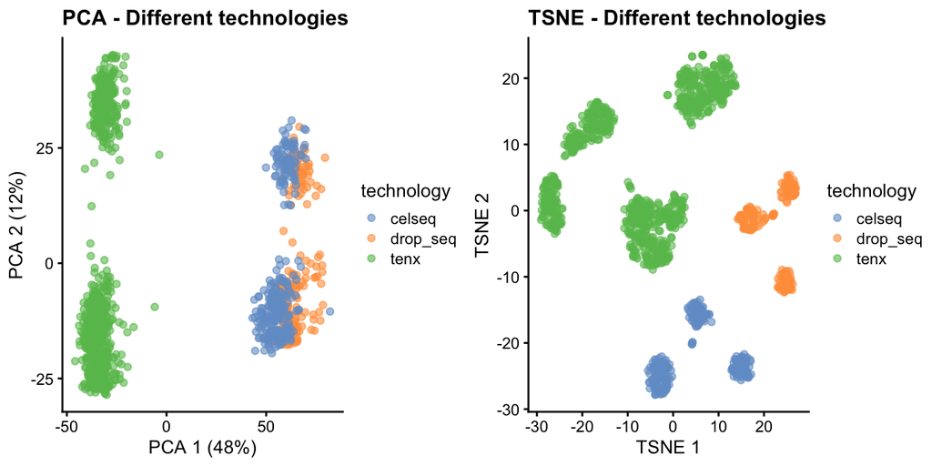

```r
# plot PCA and Tsne
multiplot(cols = 2,
  plotPCA(sce_com, colour_by = "technology") +
    ggtitle("PCA - Different technologies"),
  plotTSNE(sce_com, colour_by = "technology") +
    ggtitle("TSNE - Different technologies"))
```

```r
# The PCA/ TSNE /UMAP show that the cells are separated based on the
# sequencing technology that was used.
# The PCA and, to some extent, the TSNE show that the cells from celseq and
# drop_seq are more similar.
```

- Do cells of different cell lines cluster separately? Cluster cells and check the cell line assignments of the different clusters (either using `table` or by plotting cluster assignments and cell lines in the dimension reduction plot, as above).

**Solution**:

```r
# Clustering
g <- buildSNNGraph(sce_com, use.dimred="PCA")
cluster <- igraph::cluster_fast_greedy(g)$membership
sce_com$cluster <- factor(cluster)
table(sce_com$cluster, sce_com$cell_line, sce_com$technology)
```

```
## , ,  = celseq
##
##
##     H1975 H2228 HCC827
##   1     0     0      0
##   2     0     0      0
##   3   112     0      0
##   4     0     0      0
##   5     0    81      0
##   6     2     0     78
##   7     0     0      0
##   8     0     0      0
##   9     0     0      1
##
## , ,  = drop_seq
##
##
##     H1975 H2228 HCC827
##   1     0     0      0
##   2     0     0      0
##   3     0     0      0
##   4     0    65      0
##   5     0     0      0
##   6     0     0      0
##   7     0     0      0
##   8     0     0      0
##   9    92     0     68
##
## , ,  = tenx
##
##
##     H1975 H2228 HCC827
##   1   172     0      0
##   2     0   314      0
##   3     0     0      0
##   4     0     0      0
##   5     0     0      0
##   6     0     0      0
##   7   140     1      0
##   8     1     0    274
##   9     0     0      0
```

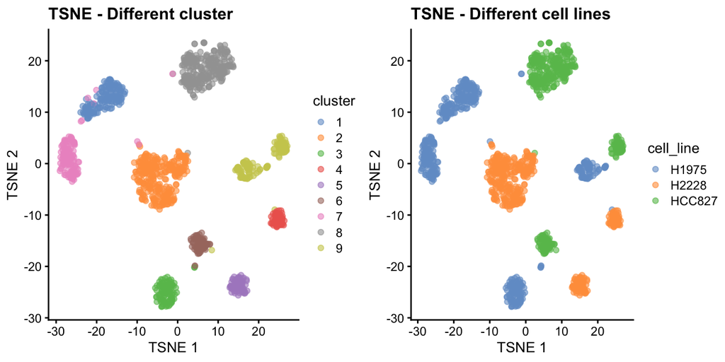

```r
# Plot colored by cell lines and cluster
multiplot(cols = 2,
  plotTSNE(sce_com, colour_by = "cluster") +
    ggtitle("TSNE - Different cluster"),
  plotTSNE(sce_com, colour_by = "cell_line") +
    ggtitle("TSNE - Different cell lines"))
```

- **(optional)** What are the marker genes for each cluster? How many markers do you find? Why do we only find so few markers for some clusters ? Plot their expression in a violinplot. **Hint**: to get better cluster markers, consider using the `block` argument of `findMarkers`. Check `?findMarkers` and `?pairwiseTTests` for details.